# SARS-CoV-2 protein expression

12-05-2021

## Introduction

## Project background

- SARS-CoV-2 emerged at the end of 2019 as the cause of COVID-19.
- High infectivity has resulted in a still ongoing pandemic.
- There is no current treatment.
- **Currently only little knowledge about the effect of COVID-19 infection on host cell gene expression.**

## Project Aim

*Aim: To carry out tidy data analysis of proteomics data, and communicate the findings to non-bioinformaticians in a way that enables them to get information about their genes of choice.*

## Materials

## Project data

- Data obtained from [Bojkova *et al.*](https://doi.org/10.1038/s41586-020-2332-7)
- Infection profile of SARS-CoV-2 using a human cell-culture model.
  - Infection (**Corona**) or **mock**-infection of **Caco-2** (colon epithilial carcinoma cells)

## Project Data

- Protein expression at **four different time** points.
- For each time point we have **triplicates**
- Cells lysed and lysate fed into **LC-MS/MS** to generate **protein counts**.

## Project Data

- Investigate genes and pathways that are altered during infection.
- Dataset consisting of two files to be joined and cleaned:
  - **Gene counts** and **sample meta-information**.

## Methods

## Methods

- Everything done in **Tidyverse** R.
- Done through **Github** to emphasize project collaboration

## Project overview

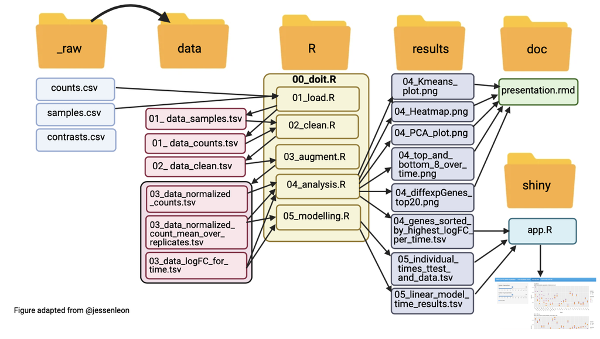

## Handling zeros

- Replace with a **small value**.
- An inherent problem for -omics and when handling compositional data in general.

## Data augmentation

- After cleaning data was **normalized**
- Normalization is due to different samplesizes
- **FPKM** equivalent **not feasible**
  - **Big genes** are not necessarily translated more
- One data frame is kept that has **ALL** the replicate information

## Data augmentation

- We calculated **means** for **conditions** over **replicates**.
- Since this is **loss** of information we saved new data tibble

## Data augmentation

- We used the triplicate means to calculate a **Log fold change**
- Log fold change was calculated between **treatment** at the different **timepoints**
- Saved a **new data frame**

## Exploratory Analysis

- **PCA** was performed to check for groupings in the normalized **count** data
- K-means to see if any particular **grouping** showed up
- A **heatmap** was also constructed to look for gene clusters with similar expression

## Exploratory Analysis

- The **LogFC** the top 20 and top 8 **DE** genes were found

## Modelling

- **Linear models** were used to test:
  - Does **logFC** of genes change significantly **over time**
  - Do we see significant **differences** between **Counts** at individual **time points**

## Results

## Heatmap

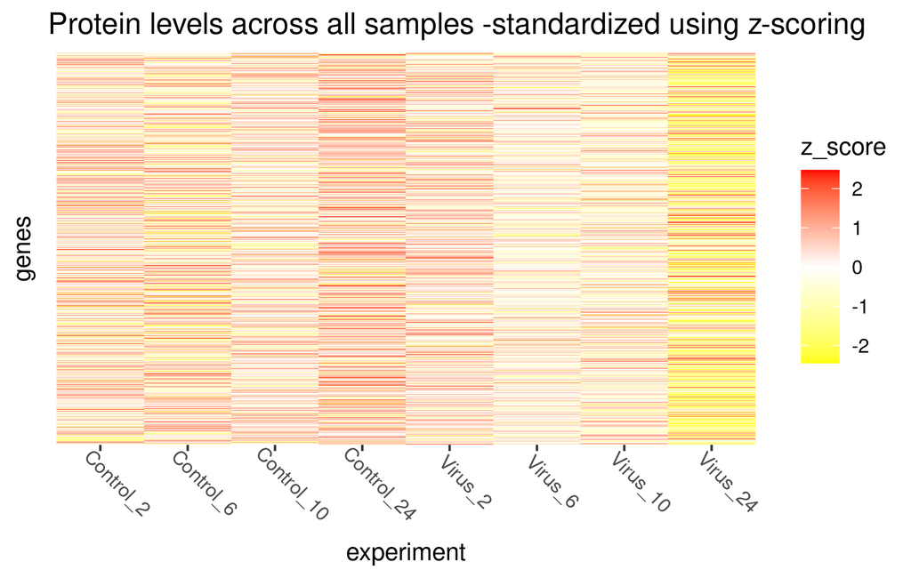

## PCA

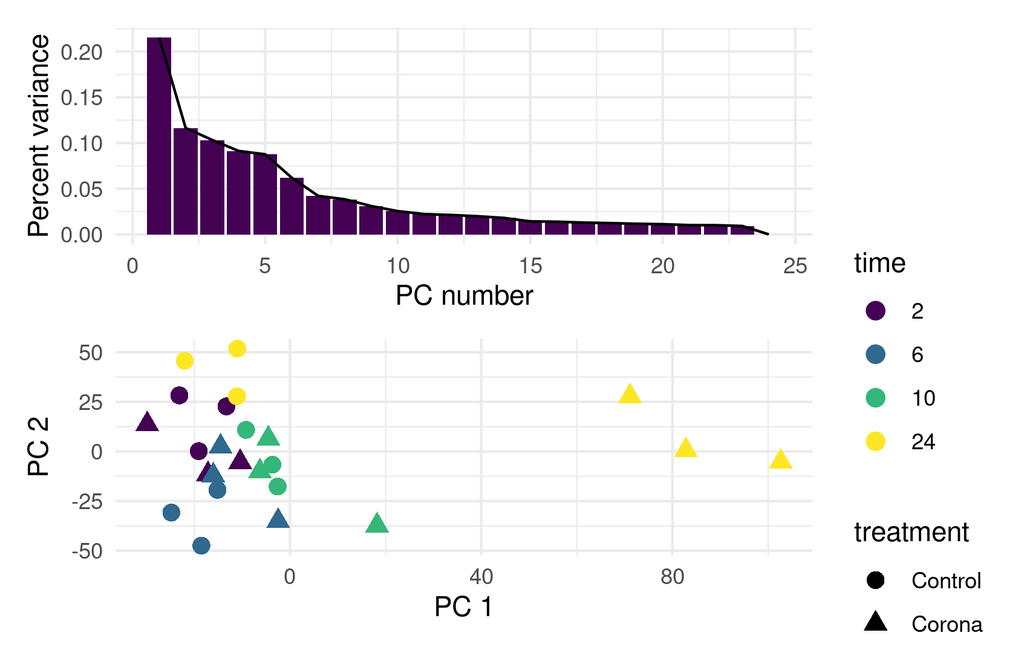

## K-means on PCA

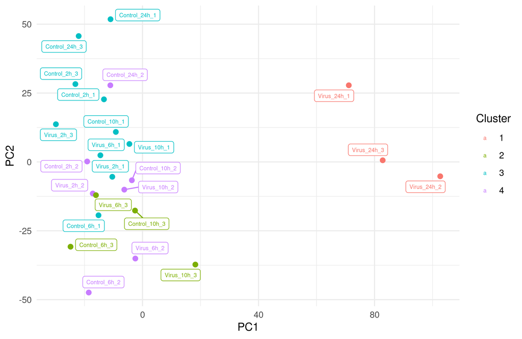

## Top upregulated DE-genes

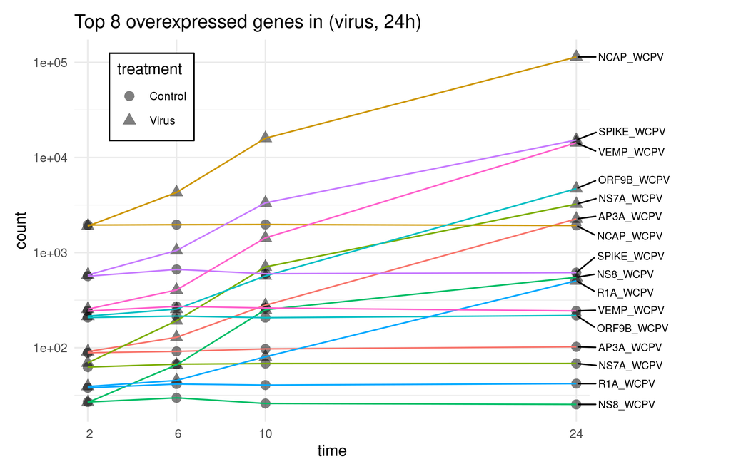

## Top downregulated DE-genes

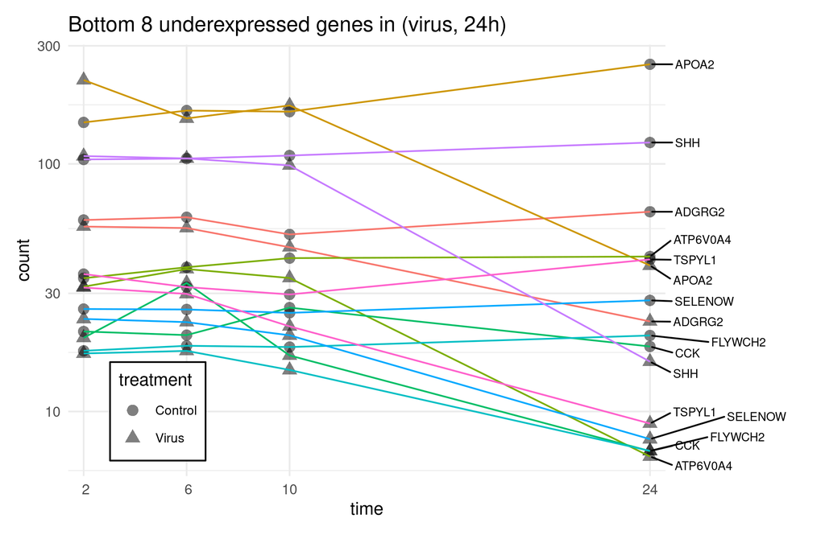

## Project overview and structure

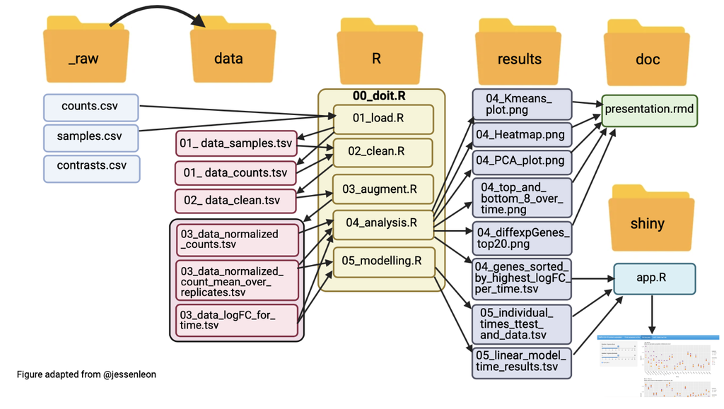

## Discussion

## Results

- A lot of the upregulated genes are in the corona genome
- Good sanity check but not the most interesting finding
- Further research into the **host DE-genes**
- Changes occur after 24 hours -incubation time
- Data came from colon epithelial cells while corona virus attacks respiratory cells

## Shiny app

- Shiny app gives a good, quick overview of protein development
- More samples would make take-aways more certain

## Workflow and methods

- Dataset makes it necessary to work in long format
- More information about function of genes and roles in pathways

## Shiny app

[interactive chart not shown]

## References

Bojkova, D., Klann, K., Koch, B. *et al.* Proteomics of SARS-CoV-2-infected host cells reveals therapy targets. Nature 583, 469–472 (2020).